# Data Visualization Project - R

Abraham Pulickakudiyil

2025-02-04

##### Metriculation Number:22302765

## **1.Installing Packages required for the task and creating working directory**

```r
#As libraries are already installed
# seting working directory
setwd("C:/Users/abrup/OneDrive/Desktop//LSI-2/Data_Vis_final_project")
```

## **2.Libraries**

```r
#loading libraries
library(tidyverse)
library(ggplot2)
library(ggpubr)
library(ggtext)
library(RColorBrewer)
library(patchwork)
library(ggrepel)
```

## **3.TCGA expression data**

### **3.1 Load and prepare data**

```r
#loading required data
tcga_cancer_csv <- read.csv("C:/Users/abrup/OneDrive/Desktop/LSI-2/Data_Vis_final_project/Data_Vis_R/tcga_cancer.csv")
tcga_cancer_labels_csv <- read.csv("C:/Users/abrup/OneDrive/Desktop/LSI-2/Data_Vis_final_project/Data_Vis_R/tcga_cancer_labels.csv")
```

```r
#preparing data
tcga_samples <- tcga_cancer_csv[0:200, 3:45]#select 200 samples for gene 1 to gene 43
tcga_samples_label <- tcga_cancer_labels_csv[1:200,]#select samples from cancer label

#Check the first few rows and columns  of the selected tcga_samples and tcga_samples_labels to check data
head(tcga_samples[,1:6])
```

```
##      gene_1   gene_2   gene_3    gene_4 gene_5   gene_6
## 1 2.0172093 3.265527 5.478487 10.431999      0 7.175175
## 2 0.5927321 1.588421 7.586157  9.623011      0 6.816049
## 3 3.5117590 4.327199 6.881787  9.870730      0 6.972130
## 4 3.6636179 4.507649 6.659068 10.196184      0 7.843375
## 5 2.6557411 2.821547 6.539454  9.738265      0 6.566967
## 6 3.4678533 3.581918 6.620243  9.706829      0 7.758510
```

```r
head(tcga_samples_label)
```

```
##          X Class
## 1 sample_0  PRAD
## 2 sample_1  LUAD
## 3 sample_2  PRAD
## 4 sample_3  PRAD
## 5 sample_4  BRCA
## 6 sample_5  PRAD
```

### **3.2 Plotting**

### **3.2.1 Expression distribution Gene1**

```r
gene1<-tcga_samples[,1]#select gene1 from tcga_samples
```

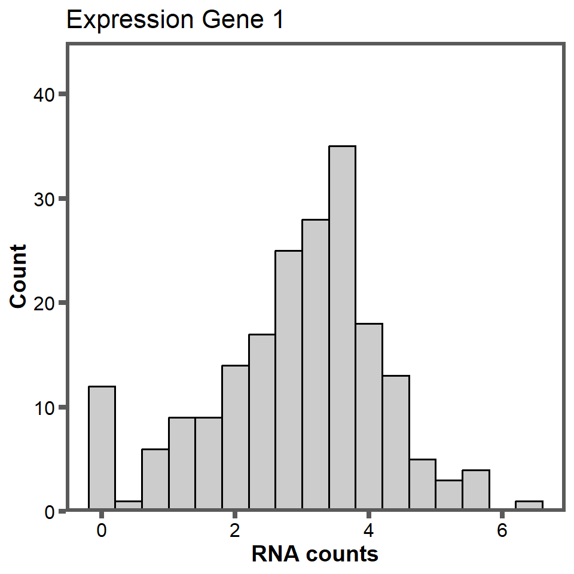

```r
histo1<-ggplot(tcga_samples, aes(x = gene1)) +
  #choose binwidth of 0.4
    geom_histogram(binwidth = 0.4, color = "black", fill = "#cccccc", linewidth  = 0.7) +
    scale_y_continuous(limits = c(0, 45), expand = c(0, 0)) +
    labs(title = "Expression Gene 1", x = "RNA counts", y = "Count") +
    theme_minimal() +
    # Customize the theme
    theme(
      axis.title = element_text(size = 14, face = "bold"),
      axis.text = element_text(size = 12, color = "black"),
      axis.ticks = element_line(color = "#5A5A5A", linewidth = 1.5),
      axis.ticks.length = unit(.15, "cm"),
      panel.grid = element_blank(), # No grid
      plot.title = element_text(size = 16),
      panel.background = element_rect(fill = "white"),
      panel.border = element_rect(color = "#5A5A5A", fill = NA, size = 2)
    )

print(histo1)
```

Bin width in a histogram is a value which divide the given variable into equal parts and it determine how much bar should be displayed in the plot and also it depends on the characteristics of our data set and the insight which we want to derive from it .

If bin width is small it will provide more details which include small fluctuations